# Trabajo Final Grupal.

Diego Maquedano Pedrero, Lucas Martínez López, José Antonio Vaquero Chaves

10/01/2021

# Introducción y preproceso de los datos

Como trabajo final hemos escogido el fichero con los datos correspondientes al World Economic Freedom Index con la intención de conocer en mayor profundidad cómo se relacionan parámetros económicos con la libertad de la población y su evolución a lo largo de los últimos 20 años.

Lo primero que debemos hacer es cargar los datos. Desde Markdown no se pueden ejecutar los comando choose.files() ni choose.dir() por lo que si se intenta replicar se pueden usar tales comandos para elegir el directorio en el que estamos trabajando y esos mismos datos. En nuestro caso, vamos a fijar el directorio que estamos usando.

```r
setwd("C:/Users/Diego/Desktop/Introduction to data mining/Trabajo_final_grupal")
datos<-read.csv("DataSet.csv",row.names = 2,dec = ".",header = T)
datos$CountryID<-NULL
datos$WEBNAME<-NULL
datos$Country<-NULL
```

Con este primer código hemos descargado los datos del csv fijando como nombre de filas cada uno de los países, poniendo usar como separador decimal el símbolo “.” y después eliminando las variables Country ID, WEBPAGE y Country puesto que son redundantes y no aportan ninguna informmación.

Ahora echamos un vistazo a los datos para conocer su estructura con un head

```r
head(datos)
```

```
##                                   Region World.Rank Region.Rank X2019.Score
## Afghanistan                 Asia-Pacific        152          39        51.5
## Albania                           Europe         52          27        66.5
## Algeria     Middle East and North Africa        171          14        46.2
## Angola                Sub-Saharan Africa        156          33        50.6
## Argentina                       Americas        148          26        52.2
## Armenia                           Europe         47          24        67.7
##             Property.Rights Judical.Effectiveness Government.Integrity
## Afghanistan            19.6                  29.6                 25.2
## Albania                54.8                  30.6                 40.4
## Algeria                31.6                  36.2                 28.9
## Angola                 35.9                  26.6                 20.5
## Argentina              47.8                  44.5                 33.5
## Armenia                57.2                  46.3                 38.6
##             Tax.Burden Gov.t.Spending Fiscal.Health Business.Freedom
## Afghanistan       91.7           80.3          99.3             49.2
## Albania           86.3           73.9          80.6             69.3
## Algeria           76.4           48.7          18.7             61.6
## Angola            83.9           80.7          58.2             55.7
## Argentina         69.3           49.5            33             56.4
## Armenia           84.7             79            53             78.3
##             Labor.Freedom Monetary.Freedom Trade.Freedom Investment.Freedom
## Afghanistan          60.4             76.7            66                 10
## Albania              52.7             81.5          87.8                 70
## Algeria              49.9             74.9          67.4                 30
## Angola               58.8             55.4          61.2                 30
## Argentina            46.9             60.2            70                 55
## Armenia              71.4             77.8          80.8                 75
##             Financial.Freedom Tariff.Rate.... Income.Tax.Rate....
## Afghanistan                10               7                  20
## Albania                    70             1.1                  23
## Algeria                    30             8.8                  35
## Angola                     40             9.4                  17
## Argentina                  60             7.5                  35
## Armenia                    70             2.1                  26
##             Corporate.Tax.Rate.... Tax.Burden...of.GDP
## Afghanistan                     20                   5
## Albania                         15                24.9
## Algeria                         23                24.5
## Angola                          30                20.6
```

[output cut: 15 more lines]

```
## Armenia                 $28.30                  7.5                         3.6
##             GDP.per.Capita..PPP. Unemployment.... Inflation....
## Afghanistan              $1,958               8.8             5
## Albania                 $12,507              13.9             2
## Algeria                 $15,237                10           5.6
## Angola                   $6,753               8.2          31.7
## Argentina               $20,876               8.7          25.7
## Armenia                  $9,456              18.2           0.9
##             FDI.Inflow..Millions. Public.Debt....of.GDP.
## Afghanistan                  53.9                    7.3
## Albania                  1,119.10                   71.2
## Algeria                  1,203.00                   25.8
## Angola                  -2,254.50                   65.3
## Argentina               11,857.00                   52.6
## Armenia                     245.7                   53.5
```

Casi todas las variables parecen estar bien salvo las columnas 23 y 26 que presentan símbolos “$" y caracteres no numéricos por lo que para un correcto análisis deberemos solucionarlo. Primero nos deshacemos del símbolo "$”

```r
datos$GDP..Billions..PPP.<-gsub('[$]','',datos$GDP..Billions..PPP.)
datos$GDP.per.Capita..PPP.<-gsub('[$]','',datos$GDP.per.Capita..PPP.)
```

A continuación eliminamos los espacios al final de cada número

```r
datos$GDP..Billions..PPP.<-trimws(datos$GDP..Billions..PPP.)
datos$GDP.per.Capita..PPP.<-trimws(datos$GDP.per.Capita..PPP.)
```

Por último se deben eliminar las comas de los miles usando de nuevo gsub para lo cual, usamos una función apply. Guardamos los nombres de las líneas porque al hacer apply nos convierte en matriz el data frame y elimina los nombres de las filas

```r
nombres<-rownames(datos)
region<-datos$Region
datos<-apply(datos[,-1], 2, function(y) as.numeric(gsub(",","",y)))
rownames(datos)<-nombres
datos<-as.data.frame(datos)
datos$Region<-region
```

Una vez están limpiados los datos, vemos su estructura para verificarlo y también comprobamos si hay valores N/A

```r
str(datos)
```

```
## 'data.frame':    186 obs. of  30 variables:
##  $ World.Rank                 : num  152 52 171 156 148 47 5 31 60 76 ...
##  $ Region.Rank                : num  39 27 14 33 26 24 4 16 13 15 ...
##  $ X2019.Score                : num  51.5 66.5 46.2 50.6 52.2 67.7 80.9 72 65.4 62.9 ...
##  $ Property.Rights            : num  19.6 54.8 31.6 35.9 47.8 57.2 79.1 84.2 59.1 42.2 ...
##  $ Judical.Effectiveness      : num  29.6 30.6 36.2 26.6 44.5 46.3 86.5 71.3 53.1 46.9 ...
##  $ Government.Integrity       : num  25.2 40.4 28.9 20.5 33.5 38.6 79.9 77.4 44.7 43.7 ...
##  $ Tax.Burden                 : num  91.7 86.3 76.4 83.9 69.3 84.7 62.8 50.5 87.5 97.3 ...
##  $ Gov.t.Spending             : num  80.3 73.9 48.7 80.7 49.5 79 60.1 24.5 59.5 86.8 ...
##  $ Fiscal.Health              : num  99.3 80.6 18.7 58.2 33 53 86.2 85.5 89.4 65.7 ...
##  $ Business.Freedom           : num  49.2 69.3 61.6 55.7 56.4 78.3 88.3 74.9 69.5 68.5 ...
##  $ Labor.Freedom              : num  60.4 52.7 49.9 58.8 46.9 71.4 84.1 68.7 63.9 67.5 ...
##  $ Monetary.Freedom           : num  76.7 81.5 74.9 55.4 60.2 77.8 86.6 81.5 63 78.1 ...
##  $ Trade.Freedom              : num  66 87.8 67.4 61.2 70 80.8 87.6 86 74.6 47.8 ...
##  $ Investment.Freedom         : num  10 70 30 30 55 75 80 90 60 50 ...
```

[output cut: 16 more lines]

```r
sum(is.na(datos))
```

```
## [1] 102
```

Todas las variables ya son numéricas a (a excepción de la región) pero hay 102 valores que son NA y que debemos sustituir por valores para poder hacer un análisis adecuado pues eliminar las obervaciones no es ideal al no disponer de un tamaño grande de muestra.

No existe una sobre cuántos NA son aceptables o cuándo hay que eliminar las observaciones pero el convenio es que no es bueno que una variable contenga más de un 5% de valores NA. Para ver esto, usamos el siguiente comando.

```r
NAtotales <- function(x){sum(is.na(x))/length(x)*100}
apply(datos,2,NAtotales)
```

```
##                  World.Rank                 Region.Rank
##                   3.2258065                   3.2258065
##                 X2019.Score             Property.Rights
##                   3.2258065                   0.5376344
##       Judical.Effectiveness        Government.Integrity
##                   0.5376344                   0.5376344
##                  Tax.Burden              Gov.t.Spending
##                   3.2258065                   1.6129032
##               Fiscal.Health            Business.Freedom
##                   1.6129032                   0.5376344
##               Labor.Freedom            Monetary.Freedom
##                   1.0752688                   1.0752688
##               Trade.Freedom          Investment.Freedom
##                   2.1505376                   1.0752688
##           Financial.Freedom             Tariff.Rate....
##                   2.6881720                   2.1505376
##         Income.Tax.Rate....      Corporate.Tax.Rate....
##                   1.6129032                   1.6129032
##         Tax.Burden...of.GDP  Gov.t.Expenditure...of.GDP
##                   3.7634409                   2.1505376
##       Population..Millions.         GDP..Billions..PPP.
##                   0.5376344                   1.6129032
##         GDP.Growth.Rate.... X5.Year.GDP.Growth.Rate....
##                   1.0752688                   1.6129032
##        GDP.per.Capita..PPP.            Unemployment....
##                   2.1505376                   3.2258065
##               Inflation....       FDI.Inflow..Millions.
##                   2.1505376                   2.6881720
##      Public.Debt....of.GDP.                      Region
##                   2.1505376                   0.0000000
```

Lo que devuelve esta función es el porcentaje de NA para cada variable. Ninguna está por encima del 5% así que lo mejor es emplear métodos que rellenen esos valores.

Para entender cómo es la ausencia de datos y tratar de predecirlos usaremos los paquetes VIM y mice. A continuación se muestra una representación de los datos faltantes

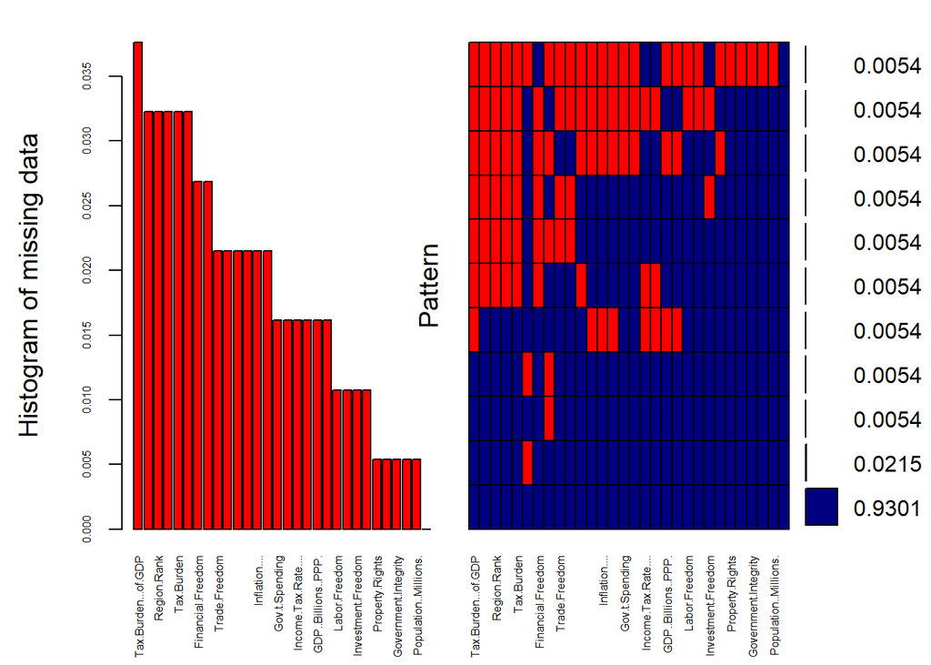

```
##
##  Variables sorted by number of missings:
##                     Variable       Count
##          Tax.Burden...of.GDP 0.037634409
##                   World.Rank 0.032258065
##                  Region.Rank 0.032258065
##                  X2019.Score 0.032258065
##                   Tax.Burden 0.032258065
##             Unemployment.... 0.032258065
##            Financial.Freedom 0.026881720
##        FDI.Inflow..Millions. 0.026881720
##                Trade.Freedom 0.021505376
##              Tariff.Rate.... 0.021505376
##   Gov.t.Expenditure...of.GDP 0.021505376
##         GDP.per.Capita..PPP. 0.021505376
##                Inflation.... 0.021505376
##       Public.Debt....of.GDP. 0.021505376
##               Gov.t.Spending 0.016129032
##                Fiscal.Health 0.016129032
##          Income.Tax.Rate.... 0.016129032
##       Corporate.Tax.Rate.... 0.016129032
##          GDP..Billions..PPP. 0.016129032
##  X5.Year.GDP.Growth.Rate.... 0.016129032
##                Labor.Freedom 0.010752688
##             Monetary.Freedom 0.010752688
##           Investment.Freedom 0.010752688
##          GDP.Growth.Rate.... 0.010752688
##              Property.Rights 0.005376344
##        Judical.Effectiveness 0.005376344
##         Government.Integrity 0.005376344
##             Business.Freedom 0.005376344
##        Population..Millions. 0.005376344
##                       Region 0.000000000
```

```r
library(VIM)
aggr_plot <- aggr(datos, col=c('navyblue','red'), numbers=TRUE, sortVars=TRUE, labels=names(data), cex.axis=.5, gap=1, ylab=c("Histogram of missing data","Pattern"))
```

La información que nos proporciona es que un 93% de las observaciones no contiene ningún NA. Con el paquete mice podemos solventar bastante bien la imputación de los datos.

```r
library(mice)
datos_sustituidos <- mice(datos,m=5,maxit=5,method ='pmm',seed=500)
summary(datos_sustituidos)
```

```
## Class: mids
## Number of multiple imputations:  5
## Imputation methods:
##                  World.Rank                 Region.Rank
##                       "pmm"                       "pmm"
##                 X2019.Score             Property.Rights
##                       "pmm"                       "pmm"
##       Judical.Effectiveness        Government.Integrity
##                       "pmm"                       "pmm"
##                  Tax.Burden              Gov.t.Spending
##                       "pmm"                       "pmm"
##               Fiscal.Health            Business.Freedom
##                       "pmm"                       "pmm"
##               Labor.Freedom            Monetary.Freedom
##                       "pmm"                       "pmm"
##               Trade.Freedom          Investment.Freedom
##                       "pmm"                       "pmm"
##           Financial.Freedom             Tariff.Rate....
##                       "pmm"                       "pmm"
##         Income.Tax.Rate....      Corporate.Tax.Rate....
##                       "pmm"                       "pmm"
##         Tax.Burden...of.GDP  Gov.t.Expenditure...of.GDP
##                       "pmm"                       "pmm"
##       Population..Millions.         GDP..Billions..PPP.
##                       "pmm"                       "pmm"
##         GDP.Growth.Rate.... X5.Year.GDP.Growth.Rate....
##                       "pmm"                       "pmm"
##        GDP.per.Capita..PPP.            Unemployment....
##                       "pmm"                       "pmm"
##               Inflation....       FDI.Inflow..Millions.
##                       "pmm"                       "pmm"
##      Public.Debt....of.GDP.                      Region
##                       "pmm"                          ""
## PredictorMatrix:
##                       World.Rank Region.Rank X2019.Score Property.Rights
## World.Rank                     0           1           1               1
## Region.Rank                    1           0           1               1
## X2019.Score                    1           1           0               1
## Property.Rights                1           1           1               0
## Judical.Effectiveness          1           1           1               1
```

[output cut: 64 more lines]

```
##                       FDI.Inflow..Millions. Public.Debt....of.GDP. Region
## World.Rank                                1                      1      0
## Region.Rank                               1                      1      0
## X2019.Score                               1                      1      0
## Property.Rights                           1                      1      0
## Judical.Effectiveness                     1                      1      0
## Government.Integrity                      1                      1      0
## Number of logged events:  451
##   it im             dep     meth         out
## 1  0  0                 constant      Region
## 2  1  1      World.Rank      pmm X2019.Score
## 3  1  1     Region.Rank      pmm X2019.Score
## 4  1  1      Tax.Burden      pmm X2019.Score
## 5  1  1   Trade.Freedom      pmm X2019.Score
## 6  1  1 Tariff.Rate....      pmm X2019.Score
```

En este caso se han generado 5 datasets copia al original con 5 iteraciones para cada uno (con más potencia se podría hacer más veces) y mediante media predictiva o pmm obtiene predicciones de los valores faltantes.

Con la función complete, obtenemos el dataset original con los datos que faltaban ya fijados.

```r
datos <- complete(datos_sustituidos,1)
```

Comprobamos la densidad de los datos “copiados” en magenta para cada una de las variables con la distribución que siguen los originales (en azul) y salvo los datos muy atípicos, vemos que se ajustan bastante bien.

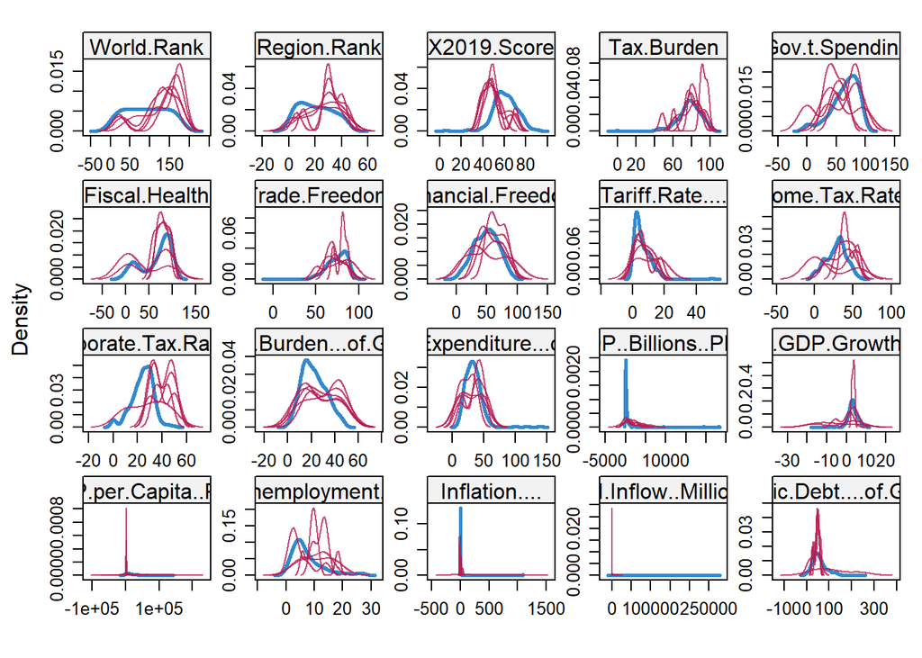

```r
densityplot(datos_sustituidos)
```